# Mengatasi Ketidakstasioneran

Berliana Destari Hermansyah

2025-09-26

```r
library(ggplot2)
library(tsibble)
library(tseries)
library(MASS)
library(readxl)
library(ggpubr)
library(forecast)
library(TSA)
```

## Input Data

```r
library(readxl)
dataiklim <- read_excel("C:/mpdwbos/mpdw/PERTEMUAN 2/dataiklimharian.xlsx", sheet = "iklim")
head(dataiklim)
```

```
## # A tibble: 6 × 2
##   Periode TAVG
##     <dbl> <chr>
## 1       1 27.2
## 2       2 27.1
## 3       3 27.8
## 4       4 26.9
## 5       5 28.4
## 6       6 27.4
```

```r
print("Struktur Data")
```

```
## [1] "Struktur Data"
```

```r
str(dataiklim)
```

```
## tibble [125 × 2] (S3: tbl_df/tbl/data.frame)
##  $ Periode: num [1:125] 1 2 3 4 5 6 7 8 9 10 ...
##  $ TAVG   : chr [1:125] "27.2" "27.1" "27.8" "26.9" ...
```

```r
print("Contoh Data")
```

```
## [1] "Contoh Data"
```

```r
head(dataiklim, 10)
```

```
## # A tibble: 10 × 2
##    Periode TAVG
##      <dbl> <chr>
##  1       1 27.2
##  2       2 27.1
##  3       3 27.8
##  4       4 26.9
##  5       5 28.4
##  6       6 27.4
##  7       7 26.4
##  8       8 26.6
##  9       9 25.5
## 10      10 27
```

```r
# Konversi data TAVG menjadi numerik dan cek missing values
tavg_data <- as.numeric(dataiklim$TAVG)
# Cek missing values
print("Missing values")
```

```
## [1] "Missing values"
```

```r
print(paste("Jumlah total observasi:", length(tavg_data)))
```

```
## [1] "Jumlah total observasi: 125"
```

```r
print(paste("Jumlah missing values (NA):", sum(is.na(tavg_data))))
```

```
## [1] "Jumlah missing values (NA): 1"
```

```r
print(paste("Persentase missing values:", round(sum(is.na(tavg_data))/length(tavg_data)*100, 2), "%"))
```

```
## [1] "Persentase missing values: 0.8 %"
```

```r
# Posisi missing values
if(sum(is.na(tavg_data)) > 0) {
  na_positions <- which(is.na(tavg_data))
  print("Posisi missing values:")
  print(na_positions)
}
```

```
## [1] "Posisi missing values:"
## [1] 112
```

## Cleaning Data

```r
tavg_clean <- na.omit(tavg_data)
print(paste("jumlah observasi:", length(tavg_clean)))
```

```
## [1] "jumlah observasi: 124"
```

```r
tavg_ts <- ts(tavg_clean)

print("Statistik Deskriptif")
```

```
## [1] "Statistik Deskriptif"
```

```r
print(paste("Jumlah observasi:", length(tavg_ts)))
```

```
## [1] "Jumlah observasi: 124"
```

```r
print(paste("Mean TAVG:", round(mean(tavg_ts), 4)))
```

```
## [1] "Mean TAVG: 27.0653"
```

```r
print(paste("Variance TAVG:", round(var(tavg_ts), 4)))
```

```
## [1] "Variance TAVG: 0.8346"
```

```r
print(paste("Min TAVG:", round(min(tavg_ts), 4)))
```

```
## [1] "Min TAVG: 23.4"
```

```r
print(paste("Max TAVG:", round(max(tavg_ts), 4)))
```

```
## [1] "Max TAVG: 28.9"
```

## Partisi Data menjadi Train dan Test

```r
# Tentukan proporsi data training (misalnya 80% untuk train, 20% untuk test)
train_size <- floor(0.8 * length(tavg_clean))

# Bagi data
tavg_train <- tavg_clean[1:train_size]
tavg_test <- tavg_clean[(train_size + 1):length(tavg_clean)]

# Konversi ke time series
tavg_train_ts <- ts(tavg_train)
tavg_test_ts <- ts(tavg_test)

print("=== INFORMASI PARTISI DATA ===")
```

```
## [1] "=== INFORMASI PARTISI DATA ==="
```

```r
print(paste("Total observasi:", length(tavg_clean)))
```

```
## [1] "Total observasi: 124"
```

```r
print(paste("Data Training:", length(tavg_train_ts), "observasi"))
```

```
## [1] "Data Training: 99 observasi"
```

```r
print(paste("Data Testing:", length(tavg_test_ts), "observasi"))
```

```
## [1] "Data Testing: 25 observasi"
```

```r
print(paste("Proporsi Train/Test:", round(train_size/length(tavg_clean)*100, 2), "% / ",
            round((length(tavg_clean)-train_size)/length(tavg_clean)*100, 2), "%"))
```

```
## [1] "Proporsi Train/Test: 79.84 % /  20.16 %"
```

## Visualisasi Partisi Data

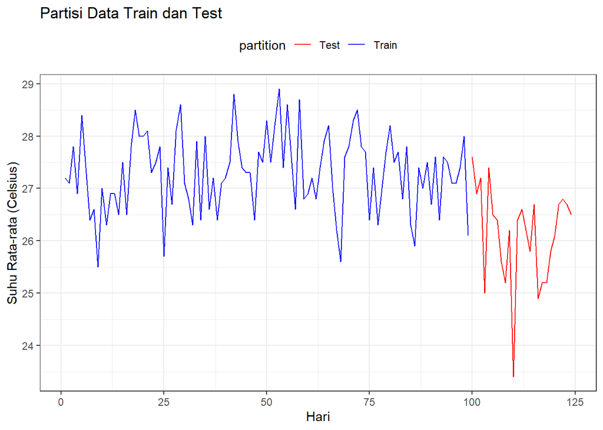

```r
# Buat dataframe untuk plotting
df_partisi <- data.frame(
  index = 1:length(tavg_clean),
  value = tavg_clean,
  partition = c(rep("Train", train_size), rep("Test", length(tavg_test)))
)

plot_partisi <- ggplot(df_partisi, aes(x = index, y = value, color = partition)) +
  geom_line() +
  scale_color_manual(values = c("Train" = "blue", "Test" = "red")) +
  theme_bw() +
  xlab("Hari") +
  ylab("Suhu Rata-rata (Celsius)") +
  ggtitle("Partisi Data Train dan Test") +
  theme(legend.position = "top")

print(plot_partisi)
```

## Analisis Stasioneritas Data Train

## 1. Plot Time Series Data Train

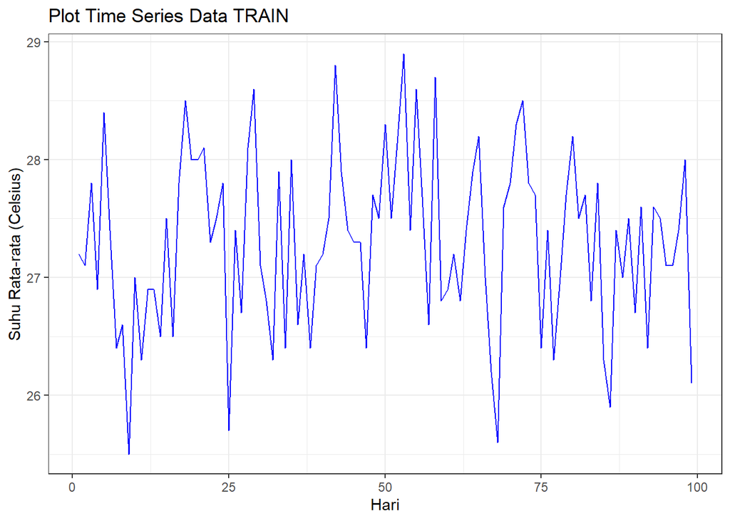

```r
tavg_train_df <- data.frame(
  index = 1:length(tavg_train_ts),
  value = as.numeric(tavg_train_ts)
)

plot_train <- ggplot(tavg_train_df, aes(x = index, y = value)) +
  geom_line(color = "blue") +
  theme_bw() +
  xlab("Hari") +
  ylab("Suhu Rata-rata (Celsius)") +
  ggtitle("Plot Time Series Data TRAIN")
print(plot_train)
```

**1. Karakteristik Visual:** Data suhu rata-rata harian (TAVG) menunjukkan pola fluktuasi yang konsisten sepanjang 99 hari observasi training. Suhu bergerak dalam rentang 25.5°C hingga 29°C dengan mean di sekitar 27°C.

**A. Stasioner dalam rataan:**

Data tidak menunjukkan trend naik atau turun yang jelas. Mean tetap konstan di sekitar 27°C dari awal hingga akhir periode. Fluktuasi terjadi secara seimbang di atas dan di bawah garis horizontal mean Kesimpulan: Data stasioner dalam rataan karena tidak ada pergeseran sistematis mean

**B. Stasioner dalam ragam:**

Amplitudo fluktuasi relatif konsisten sepanjang periode Tidak ada pola “funnel shape” atau heteroskedastisitas Variabilitas di awal periode (~3°C) sama dengan di akhir periode (~2.5-3°C) Kesimpulan: Data stasioner dalam ragam karena volatilitas konstan

## 2. Plot ACF Data Train

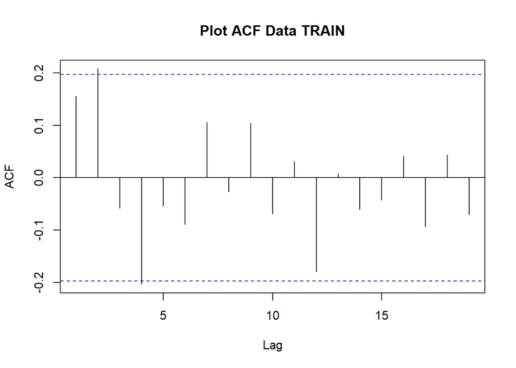

```r
par(mfrow = c(1, 1))
acf(tavg_train_ts, main = "Plot ACF Data TRAIN")
```

### **Karakteristik ACF:**

**A. Lag 0:**

- ACF = 1.0 (sempurna, karena korelasi data dengan dirinya sendiri)

## 3. Uji ADF Data Train

**Hipotesis:**

- H₀ (Null Hypothesis): Data tidak stasioner
- H₁ (Alternative Hypothesis): Data stasioner

```r
adf_train <- adf.test(tavg_train_ts)
print("=== HASIL UJI ADF DATA TRAIN ===")
```

```
## [1] "=== HASIL UJI ADF DATA TRAIN ==="
```

```r
print(adf_train)
```

```
##
##  Augmented Dickey-Fuller Test
##
## data:  tavg_train_ts
## Dickey-Fuller = -4.5529, Lag order = 4, p-value = 0.01
## alternative hypothesis: stationary
```

```r
if(adf_train$p.value < 0.05) {
  print("Kesimpulan ADF: Data TRAIN STASIONER dalam rataan (p-value < 0.05)")
} else {
  print("Kesimpulan ADF: Data TRAIN TIDAK STASIONER dalam rataan (p-value >= 0.05)")
}
```

```
## [1] "Kesimpulan ADF: Data TRAIN STASIONER dalam rataan (p-value < 0.05)"
```

**A. Statistik Uji:**

- Dickey-Fuller statistic = -4.5529
- Nilai ini sangat negatif dan jauh dari 0
- Semakin negatif nilai DF, semakin kuat bukti stasioneritas

**B. P-value:**

- **p-value = 0.01** (sangat kecil, < 0.05)
- P-value yang sangat kecil ini memberikan **bukti sangat kuat untuk menolak H₀**

**C. Lag Order:**

- Lag order = 4 dipilih otomatis oleh algoritma ADF

### **Kesimpulan Uji ADF:**

Tolak H₀ dengan sangat kuat. Data train stasioner dalam rataan (p-value = 0.01 < 0.05).

- Mean data tidak bergeser seiring waktu
- Tidak ada trend deterministik atau stokastik
- Data dapat langsung digunakan untuk pemodelan tanpa transformasi differencing

## 4. Plot Box-Cox Data Train

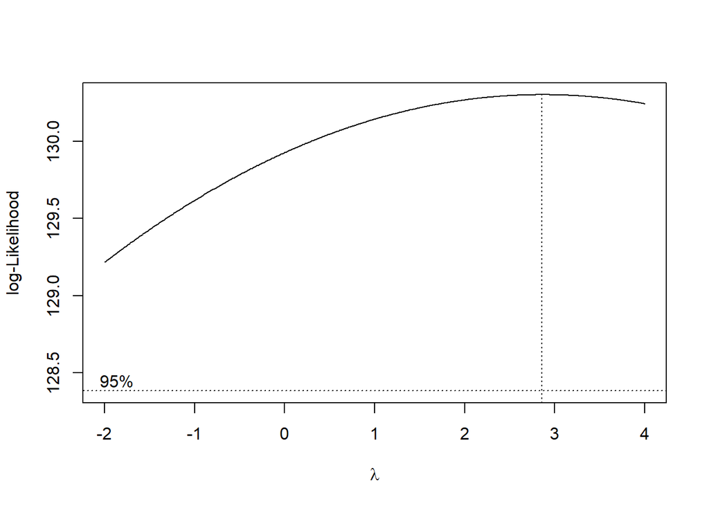

```r
# Pastikan data positif untuk Box-Cox
if(min(tavg_train_ts) <= 0) {
  tavg_train_positive <- tavg_train_ts - min(tavg_train_ts) + 1
  print("Data train digeser agar positif untuk analisis Box-Cox")
} else {
  tavg_train_positive <- tavg_train_ts
}

index_train <- seq(1:length(tavg_train_positive))

# Box-Cox transformation
bc_train <- boxcox(tavg_train_positive ~ index_train, lambda = seq(-2, 4, by = 0.01))
```

```r
# Nilai lambda optimum
lambda_train_opt <- bc_train$x[which.max(bc_train$y)]
print(paste("Lambda optimum (Train):", round(lambda_train_opt, 3)))
```

```
## [1] "Lambda optimum (Train): 2.86"
```

```r
# Selang kepercayaan 95% untuk lambda
ci_lambda_train <- bc_train$x[bc_train$y > max(bc_train$y) - 0.5 * qchisq(0.95, 1)]
ci_lower_train <- min(ci_lambda_train)
ci_upper_train <- max(ci_lambda_train)

print(paste("Selang kepercayaan 95% lambda (Train): [",
            round(ci_lower_train, 3), ",", round(ci_upper_train, 3), "]"))
```

```
## [1] "Selang kepercayaan 95% lambda (Train): [ -2 , 4 ]"
```

```r
if(ci_lower_train <= 1 && ci_upper_train >= 1) {
  print("Kesimpulan Box-Cox: Data TRAIN STASIONER dalam ragam (selang memuat 1)")
} else {
  print("Kesimpulan Box-Cox: Data TRAIN TIDAK STASIONER dalam ragam (selang tidak memuat 1)")
}
```

```
## [1] "Kesimpulan Box-Cox: Data TRAIN STASIONER dalam ragam (selang memuat 1)"
```

### **Karakteristik Plot:**

Plot menampilkan kurva log-likelihood untuk berbagai nilai lambda transformasi Box-Cox dalam rentang -2 hingga 4.

**A. Bentuk Kurva:**

- Kurva **smooth dan berbentuk parabola terbalik**
- Kurva naik dari lambda = -2, mencapai puncak di sekitar lambda = 2.86, lalu turun menuju lambda = 4

**B. Lambda Optimum:**

- **λ_opt = 2.86**
- Ini adalah nilai lambda yang **memaksimalkan log-likelihood**
- Artinya transformasi Y^2.86 secara teoritis paling baik untuk menormalkan varians

**C. Selang Kepercayaan 95%:**

- **CI = [-2, 4]**
- Garis putus-putus horizontal menunjukkan batas selang kepercayaan

### **Interpretasi:**

**1. Status Stasioneritas dalam Ragam:**

- Ketika CI memuat 1, artinya tidak ada bukti bahwa varians tidak konstan
- λ = 1 berarti tidak perlu transformasi (karena Y^1 = Y, data asli)

**2. Lambda Optimum = 2.86:**

- Meskipun λ_opt = 2.86, tidak perlu ke transformasi Y^2.86
- Ini menunjukkan ketidakpastian tinggi dalam estimasi lambda optimal

**3. Selang Kepercayaan Sangat Lebar [-2, 4]:**

- Ini adalah indikator positif untuk kestasioneran
- Artinya berbagai transformasi (dari Y^(-2) hingga Y^4) memberikan hasil log-likelihood yang tidak jauh berbeda
- Data sudah memenuhi asumsi homoskedastisitas

## 5. Spesifikasi Model

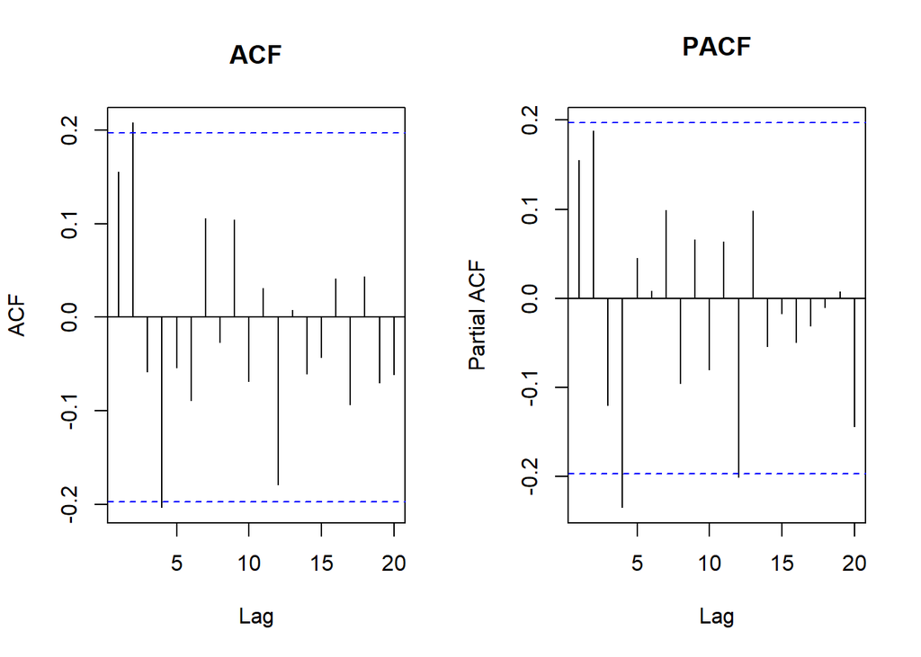

```r
par(mfrow = c(1,2))
acf(tavg_train, main="ACF", lag.max=20) #ARIMA(0,0,2)
pacf(tavg_train, main="PACF", lag.max=20) #ARIMA(1,0,0)
```

```r
par(mfrow = c(1,1))
```

```r
is.ts(tavg_train_ts)
```

```
## [1] TRUE
```

```r
library(TSA)
eacf(tavg_train_ts)
```

```
## AR/MA
##   0 1 2 3 4 5 6 7 8 9 10 11 12 13
## 0 o x o o o o o o o o o  o  o  o
## 1 x x o o o o o o o o o  o  o  o
## 2 x x o x o o o o o o o  o  o  o
## 3 x x o o o o o o o o o  o  o  o
## 4 x o x o o o o o o o o  o  o  o
## 5 o o x o o o o o o o o  o  o  o
## 6 o x x o o o o o o o o  o  o  o
## 7 x o o o o o o o o o o  o  o  o
```

Dengan demikian, berdasarkan hasil analisis EACF, model tentatif yang paling mungkin sesuai dengan data adalah ARIMA(1,0,2), ARIMA(2,0,2), dan ARIMA(3,0,2), yang selanjutnya akan diuji pada tahap pendugaan parameter dan evaluasi diagnostik.

## 6. Pendugaan Parameter Model Tentatif

## 6.1 ARIMA(0,1,1)

```r
model1.tavg=Arima(tavg_train_ts, order=c(0,1,1),method="ML")
summary(model1.tavg) #AIC=227.86
```

```
## Series: tavg_train_ts
## ARIMA(0,1,1)
##
## Coefficients:
##           ma1
##       -1.0000
## s.e.   0.0653
##
## sigma^2 = 0.5542:  log likelihood = -111.93
## AIC=227.86   AICc=227.99   BIC=233.03
##
## Training set error measures:
##                      ME   RMSE       MAE       MPE     MAPE      MASE      ACF1
## Training set 0.04831752 0.7369 0.5882303 0.1048497 2.156672 0.7381123 0.1522472
```

## 6.2 ARIMA(1,0,2)

```r
model2.tavg=Arima(tavg_train, order=c(1,0,2),method="ML")
summary(model2.tavg) #AIC=220.56
```

```
## Series: tavg_train
## ARIMA(1,0,2) with non-zero mean
##
## Coefficients:
##          ar1     ma1     ma2     mean
##       0.0477  0.0847  0.3528  27.2992
## s.e.  0.2237  0.2025  0.1137   0.1056
##
## sigma^2 = 0.5104:  log likelihood = -105.28
## AIC=220.56   AICc=221.2   BIC=233.53
##
## Training set error measures:
##                        ME      RMSE       MAE         MPE     MAPE      MASE
## Training set 0.0005171225 0.6998143 0.5687814 -0.06306422 2.089016 0.7137078
##                     ACF1
## Training set 0.003906712
```

## 6.3 ARIMA(2,0,2)

```r
model3.tavg=Arima(tavg_train_ts, order=c(2,0,2),method="ML")
summary(model3.tavg) #AIC=219.7
```

```
## Series: tavg_train_ts
## ARIMA(2,0,2) with non-zero mean
##
## Coefficients:
##          ar1      ar2      ma1     ma2     mean
##       0.2081  -0.4703  -0.0806  0.7602  27.3020
## s.e.  0.1694   0.2544   0.1241  0.2023   0.0919
##
## sigma^2 = 0.4998:  log likelihood = -103.85
## AIC=219.7   AICc=220.61   BIC=235.27
##
## Training set error measures:
##                        ME      RMSE       MAE         MPE     MAPE      MASE
## Training set -0.001092039 0.6888731 0.5520985 -0.06830957 2.029315 0.6927741
##                      ACF1
## Training set 0.0008890736
```

## 6.4 ARIMA(3,0,2)

```r
model4.tavg=Arima(tavg_train_ts, order=c(3,0,2),method="ML")
summary(model4.tavg) #AIC=221.7
```

```
## Series: tavg_train_ts
## ARIMA(3,0,2) with non-zero mean
##
## Coefficients:
##          ar1      ar2      ar3      ma1     ma2     mean
##       0.2083  -0.4689  -0.0013  -0.0811  0.7590  27.3021
## s.e.  0.1709   0.2988   0.1378   0.1376  0.2396   0.0918
##
## sigma^2 = 0.5052:  log likelihood = -103.85
## AIC=221.7   AICc=222.93   BIC=239.86
##
## Training set error measures:
##                        ME      RMSE       MAE         MPE     MAPE     MASE
## Training set -0.001089473 0.6888768 0.5521486 -0.06830031 2.029489 0.692837
##                     ACF1
## Training set 0.001194265
```

## Ringkasan AIC

```r
model_tentatif <- data.frame(
  Model = c("ARIMA(0,1,1)","ARIMA(1,0,2)","ARIMA(2,0,2)", "ARIMA(3,0,2)"),
  AIC   = c(AIC(model1.tavg),AIC(model2.tavg), AIC(model3.tavg), AIC(model4.tavg)),
  BIC   = c(BIC(model1.tavg),BIC(model2.tavg), BIC(model3.tavg), BIC(model4.tavg))
)

model_tentatif
```

```
##          Model      AIC      BIC
## 1 ARIMA(0,1,1) 227.8612 233.0312
## 2 ARIMA(1,0,2) 220.5574 233.5330
## 3 ARIMA(2,0,2) 219.6959 235.2666
## 4 ARIMA(3,0,2) 221.6958 239.8617
```

Berdasarkan hasil perhitungan, terdapat beberapa model tentatif yang mungkin sesuai dengan data, yaitu ARIMA(0,1,1),ARIMA(1,0,2), ARIMA(2,0,2), dan ARIMA(3,0,2). Berdasarkan nilai AIC yang paling rendah, model terbaik sementara adalah ARIMA(1,0,2) atau ARIMA(2,0,2).

## 7. Eksplorasi Sisaan

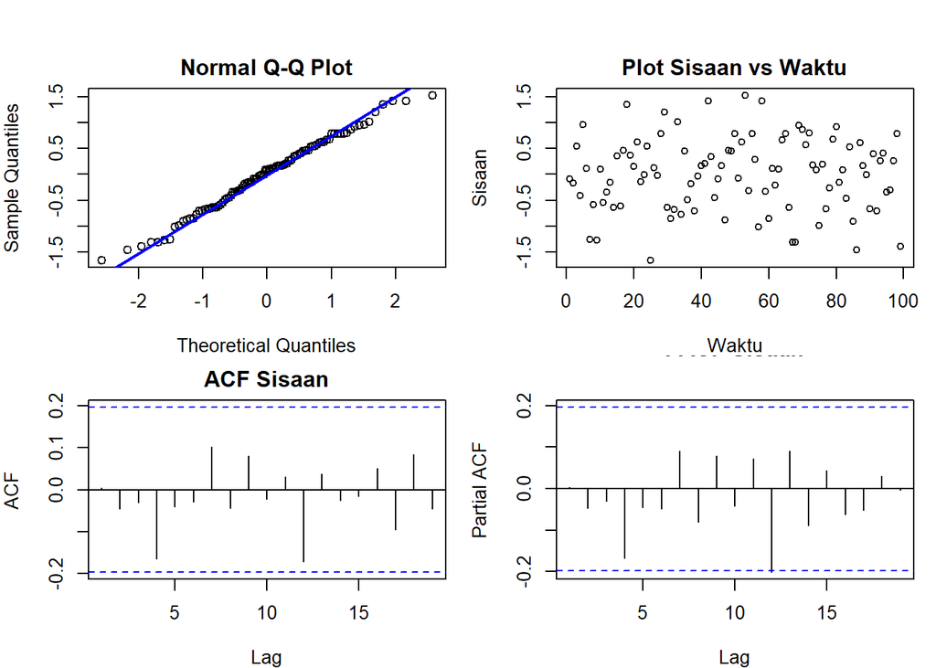

```r
sisaan.tavg <- model2.tavg$residuals

par(mfrow = c(2,2),
    mar = c(4,4,2,1),
    oma = c(0,0,2,0))

# Q-Q Plot
qqnorm(sisaan.tavg, main = "Normal Q-Q Plot")
qqline(sisaan.tavg, col = "blue", lwd = 2)

# Plot Sisaan vs Waktu
plot(sisaan.tavg, type = "p",
     main = "Plot Sisaan vs Waktu",
     xlab = "Waktu", ylab = "Sisaan")

# ACF
acf(sisaan.tavg, main = "ACF Sisaan")

# PACF
pacf(sisaan.tavg, main = "PACF Sisaan")
```

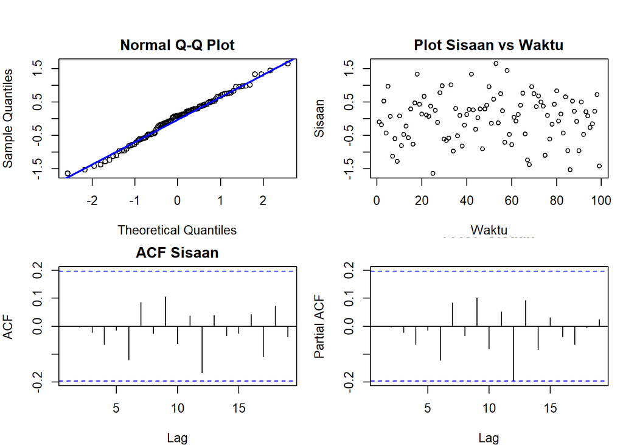

```r
sisaan.tavg <- model3.tavg$residuals

par(mfrow = c(2,2),
    mar = c(4,4,2,1),
    oma = c(0,0,2,0))

# Q-Q Plot
qqnorm(sisaan.tavg, main = "Normal Q-Q Plot")
qqline(sisaan.tavg, col = "blue", lwd = 2)

# Plot Sisaan vs Waktu
plot(sisaan.tavg, type = "p",
     main = "Plot Sisaan vs Waktu",
     xlab = "Waktu", ylab = "Sisaan")

# ACF
acf(sisaan.tavg, main = "ACF Sisaan")

# PACF
pacf(sisaan.tavg, main = "PACF Sisaan")
```

```r
#1) Sisaan Menyebar Normal
ks.test(sisaan.tavg,"pnorm")  #gagal tolak H0 > sisaan menyebar normal
```

```
##
##  Exact one-sample Kolmogorov-Smirnov test
##
## data:  sisaan.tavg
## D = 0.11853, p-value = 0.1141
## alternative hypothesis: two-sided
```

Selain dengan eksplorasi, asumsi tersebut dapat diuji menggunakan uji formal. Pada tahapan ini, uji formal yang digunakan untuk menguji kenormalan adalah uji Kolmogorov–Smirnov (KS). Hipotesis yang digunakan dalam uji KS adalah sebagai berikut. H0: Sisaan menyebar normal H1: Sisaan tidak menyebar normal Berdasarkan hasil uji KS, diperoleh p-value sebesar 0.1141 yang lebih besar dari taraf nyata 5% (0.05). Dengan demikian, gagal menolak H0 yang berarti sisaan berdistribusi normal. Hasil ini sejalan dengan plot kuantil-kuantil normal, di mana titik-titik residu tampak mengikuti garis diagonal, sehingga secara visual maupun formal dapat disimpulkan bahwa asumsi kenormalan residu terpenuhi.

```r
#2) Sisaan saling bebas/tidak ada autokorelasi
Box.test(sisaan.tavg, type = "Ljung")  #gagal tolak H0 > sisaan saling bebas
```

```
##
##  Box-Ljung test
##
## data:  sisaan.tavg
## X-squared = 8.065e-05, df = 1, p-value = 0.9928
```

Selain kenormalan, asumsi lain yang perlu diuji adalah kebebasan sisaan (white noise assumption). Uji formal yang digunakan untuk menguji ada tidaknya autokorelasi pada sisaan adalah uji Box–Ljung. Hipotesis yang digunakan adalah sebagai berikut. 1. H0: Tidak ada autokorelasi pada sisaan 2. H1: Terdapat autokorelasi pada sisaan Berdasarkan hasil uji Box–Ljung, diperoleh p-value sebesar 0.9928 yang jauh lebih besar dari taraf nyata 5% (0.05). Dengan demikian, gagal menolak H0, yang berarti tidak terdapat autokorelasi pada sisaan. Hasil ini sejalan dengan plot ACF dan PACF sisaan, di mana tidak tampak spike yang signifikan. Oleh karena itu, dapat disimpulkan bahwa sisaan telah memenuhi asumsi white noise, sehingga model ARIMA yang dipilih sudah sesuai untuk data yang dianalisis.

```r
Box.test((sisaan.tavg)^2, type = "Ljung")  #gagal tolak H0 > sisaan homogen
```

```
##
##  Box-Ljung test
##
## data:  (sisaan.tavg)^2
## X-squared = 0.17257, df = 1, p-value = 0.6778
```

1. H0: Ragam sisaan homogen
2. H1: Ragam sisaan tidak homogen Berdasarkan uji Ljung–Box terhadap sisaan kuadrat, diperoleh p-value sebesar 0.6778 yang lebih besar dari taraf nyata 5% (0.05) sehingga gagal menolak H0 dan menandakan bahwa ragam sisaan bersifat homogen. Dengan demikian, dapat disimpulkan bahwa tidak terdapat heteroskedastisitas pada sisaan, atau dengan kata lain asumsi kehomogenan ragam terpenuhi pada model ARIMA yang digunakan.

```r
#4) Nilai tengah sisaan sama dengan nol
t.test(sisaan.tavg, mu = 0, conf.level = 0.95)  #gagal tolak h0 > nilai tengah sisaan sama dengan 0
```

```
##
##  One Sample t-test
##
## data:  sisaan.tavg
## t = -0.015693, df = 98, p-value = 0.9875
## alternative hypothesis: true mean is not equal to 0
## 95 percent confidence interval:
##  -0.1391844  0.1370003
## sample estimates:
##    mean of x
## -0.001092039
```

1. H0: nilai tengah sisaan sama dengan 0
2. H1: nilai tengah sisaan tidak sama dengan 0 Berdasarkan hasil uji t satu sampel (One Sample t-test), diperoleh nilai p-value sebesar 0.9875 yang lebih besar dari taraf nyata 5% (0.05). Dengan demikian, gagal menolak H0 dan dapat disimpulkan bahwa rata-rata sisaan tidak berbeda signifikan dari nol. Hal ini menunjukkan bahwa model tidak memiliki bias sistematis, atau dengan kata lain prediksi model ARIMA sudah tidak menyisakan pola tertentu dalam rata-rata sisaan.